# Practical Machine Learning Course Project

Practical Machine Learning Course Peer Graded Assignment

Yiannis Manatos

December 11, 2016

# Synopsis

This report analyzes data collected from belt, forearm, arm, and dumbbell accelerometers of 6 participants, in order to predict the manner in which they did their exercise. Participants were asked to perform one set of 10 repetitions of the Unilateral Dumbbell Biceps Curl in five different fashions: exactly according to the specification (Class A), throwing the elbows to the front (Class B), lifting the dumbbell only halfway (Class C), lowering the dumbbell only halfway (Class D) and throwing the hips to the front (Class E). Class A corresponds to the specified execution of the exercise, while the other 4 classes correspond to common mistakes.

Using devices such as Jawbone Up, Nike FuelBand, and Fitbit it is now possible to collect a large amount of data about personal activity relatively inexpensively. These type of devices are part of the quantified self movement – a group of enthusiasts who take measurements about themselves regularly to improve their health, to find patterns in their behavior, or just because they are tech geeks. One thing that people regularly do is quantify how much of a particular activity they do, but they rarely quantify how well they do it. In this project, your goal will be to use data from accelerometers on the belt, forearm, arm, and dumbell of 6 participants, and predict the manner in which participants did the exercise. The $classe$ variable in the training set takes on 1 of the 5 Classes (i.e. $A$, $B$, $C$, $D$, $E$).

More information is available from the website here: http://groupware.les.inf.puc-rio.br/har (see the section on the Weight Lifting Exercise Dataset).

## Data

The training data for this project are available here: https://d396qusza40orc.cloudfront.net/predmachlearn/pml-training.csv.

The test data are available here: https://d396qusza40orc.cloudfront.net/predmachlearn/pml-testing.csv

The data for this project come from this source: http://groupware.les.inf.puc-rio.br/har. If you use the document you create for this class for any purpose please cite them as they have been very generous in allowing their data to be used for this kind of assignment.

# Data loading and pre-processing

```r
# Data setup
data.training <- read.csv("pml-training.csv", header = TRUE, sep = ",")
data.testing <- read.csv("pml-testing.csv", header = TRUE, sep = ",")
```

**Training set** basic properties inspection is shown at Appendix #1. We see $19622$ samples from $6$ individuals (adelmo, carlitos, charles, eurico, jeremy, pedro), where the $classe$ factor variable can take any of the values $A, B, C, D, E$.

**Testing set** is shown at Appendix #2. We see $20$ samples from the same $6$ individuals (adelmo, carlitos, charles, eurico, jeremy, pedro), where the $classe$ variable has been replaced by a $problem\_id$ integer variable with incremental values in the range $1 - 20$.

## Remove some variables

Then, it is observed that the first $X$ variable is an incremental row counter, in both sets. And the remained variables are either numeric/integer or categorical (factor) variables. The categorical variables most probably indicate several sensor devices settings, so we remove them from both data sets prior to data analysis. We also remove the $X$ row counters. The categorical variables to be removed from both data sets, are:

```r
# Identify all categorical (factor) variable names
factor.vars <- split(names(data.training), sapply(data.training, function(x)
    paste(class(x), collapse=" ")))$factor
print(factor.vars <- factor.vars[-which(factor.vars == 'classe')])
```

```
##  [1] "user_name"               "cvtd_timestamp"
##  [3] "new_window"              "kurtosis_roll_belt"
##  [5] "kurtosis_picth_belt"     "kurtosis_yaw_belt"
##  [7] "skewness_roll_belt"      "skewness_roll_belt.1"
##  [9] "skewness_yaw_belt"       "max_yaw_belt"
## [11] "min_yaw_belt"            "amplitude_yaw_belt"
## [13] "kurtosis_roll_arm"       "kurtosis_picth_arm"
## [15] "kurtosis_yaw_arm"        "skewness_roll_arm"
## [17] "skewness_pitch_arm"      "skewness_yaw_arm"
## [19] "kurtosis_roll_dumbbell"  "kurtosis_picth_dumbbell"
## [21] "kurtosis_yaw_dumbbell"   "skewness_roll_dumbbell"
## [23] "skewness_pitch_dumbbell" "skewness_yaw_dumbbell"
## [25] "max_yaw_dumbbell"        "min_yaw_dumbbell"
## [27] "amplitude_yaw_dumbbell"  "kurtosis_roll_forearm"
## [29] "kurtosis_picth_forearm"  "kurtosis_yaw_forearm"
## [31] "skewness_roll_forearm"   "skewness_pitch_forearm"
## [33] "skewness_yaw_forearm"    "max_yaw_forearm"
## [35] "min_yaw_forearm"         "amplitude_yaw_forearm"
```

From those, we keep only the $classe$ training variable while we also remove the $problem\_id$ testing variable.

```r
# Remove some variables
training <- data.training[, -which(names(data.training) %in%
                                       c('X', factor.vars))]
testing <- data.testing[, -which(names(data.testing) %in%
                                     c('X', factor.vars, 'problem_id'))]
```

## Remove N/A variables

```r
# Remove N/A and blank variables
print(na.vars <- names(which(sapply(training, function(x) length(which(is.na(x)))!=0))))
```

```
##  [1] "max_roll_belt"            "max_picth_belt"
##  [3] "min_roll_belt"            "min_pitch_belt"
##  [5] "amplitude_roll_belt"      "amplitude_pitch_belt"
##  [7] "var_total_accel_belt"     "avg_roll_belt"
##  [9] "stddev_roll_belt"         "var_roll_belt"
## [11] "avg_pitch_belt"           "stddev_pitch_belt"
## [13] "var_pitch_belt"           "avg_yaw_belt"
## [15] "stddev_yaw_belt"          "var_yaw_belt"
## [17] "var_accel_arm"            "avg_roll_arm"
## [19] "stddev_roll_arm"          "var_roll_arm"
## [21] "avg_pitch_arm"            "stddev_pitch_arm"
## [23] "var_pitch_arm"            "avg_yaw_arm"
## [25] "stddev_yaw_arm"           "var_yaw_arm"
## [27] "max_roll_arm"             "max_picth_arm"
## [29] "max_yaw_arm"              "min_roll_arm"
```

[output cut: 19 more lines]

From the remained variables, we identify $67$ variables with $N/A$ values, and remove them as well:

```r
# Remove N/A and blank variables
training <- training[, -which(names(training) %in% na.vars)]
testing <- testing[, -which(names(testing) %in% na.vars)]
```

## Final variables to remove

From the remained variables, the $raw\_timestamp\_part\_1$, $raw\_timestamp\_part\_2$, and $num\_window$ variables are also selected to be removed as they carry not measured values:

```r
# Remove some more variables
print(somemore.vars <- c('raw_timestamp_part_1', 'raw_timestamp_part_2', 'num_window'))
```

```
## [1] "raw_timestamp_part_1" "raw_timestamp_part_2" "num_window"
```

```r
training <- training[, -which(names(training) %in% somemore.vars)]
testing <- testing[, -which(names(testing) %in% somemore.vars)]
```

Then, the remaining variables to work with, are:

- $52$ predictor variables, and
- the $classe$ classifier (predicted variable):

```r
# Variables to work with
names(training)
```

```
##  [1] "roll_belt"            "pitch_belt"           "yaw_belt"
##  [4] "total_accel_belt"     "gyros_belt_x"         "gyros_belt_y"
##  [7] "gyros_belt_z"         "accel_belt_x"         "accel_belt_y"
## [10] "accel_belt_z"         "magnet_belt_x"        "magnet_belt_y"
## [13] "magnet_belt_z"        "roll_arm"             "pitch_arm"
## [16] "yaw_arm"              "total_accel_arm"      "gyros_arm_x"
## [19] "gyros_arm_y"          "gyros_arm_z"          "accel_arm_x"
## [22] "accel_arm_y"          "accel_arm_z"          "magnet_arm_x"
## [25] "magnet_arm_y"         "magnet_arm_z"         "roll_dumbbell"
## [28] "pitch_dumbbell"       "yaw_dumbbell"         "total_accel_dumbbell"
## [31] "gyros_dumbbell_x"     "gyros_dumbbell_y"     "gyros_dumbbell_z"
## [34] "accel_dumbbell_x"     "accel_dumbbell_y"     "accel_dumbbell_z"
## [37] "magnet_dumbbell_x"    "magnet_dumbbell_y"    "magnet_dumbbell_z"
## [40] "roll_forearm"         "pitch_forearm"        "yaw_forearm"
## [43] "total_accel_forearm"  "gyros_forearm_x"      "gyros_forearm_y"
## [46] "gyros_forearm_z"      "accel_forearm_x"      "accel_forearm_y"
## [49] "accel_forearm_z"      "magnet_forearm_x"     "magnet_forearm_y"
## [52] "magnet_forearm_z"     "classe"
```

```r
dim(training)
```

```
## [1] 19622    53
```

```r
dim(testing)
```

```
## [1] 20 52
```

# Data Processing

```r
# Set some working settings
part_perc <- 0.7        # partition percentage
modelFitNbr <- 10       # Model(s) fit number
rf_ntrees <- 100        # Number of trees to grow (random forest model)
rf_ntrees.tune <- 500   # Number of trees to grow (when tuning)
seed0 <- 1235           # Random seeding value
```

## Data partitioning

Before creating our model, we split the training data set into a working training set with the 70% of the samples, and a validation set with the remaining 30% of the training samples.

```r
# Split training data set, create a validation set
featuresPartition <- createDataPartition(y = training$classe, p = part_perc, list = FALSE)
training.train <- training[featuresPartition,]
training.validate <- training[-featuresPartition,]
dim(training.train)
```

```
## [1] 13737    53
```

```r
dim(training.validate)
```

```
## [1] 5885   53
```

This creates a new training set with $13737$ entries and a new validation set with $5885$ entries, out of our original training set. The plan is to use the working training set for training our model and the validation set to test (and fine tune) it, before applying it to the original testing set.

## Model selection

In order to select the optimal prediction model, we will create several different models, train them, and measure their predictions accuracy (using the working training and validation data sets as created above). Then, we will select the optimal accuracy model to proceed with. The candidate models to test are:

- Decision tree model, or CART (Classification And Regression Tree), and
- Random Forest model.

```r
# Model selection process
fitControl <- trainControl(method = "cv", number = modelFitNbr)
# train the models
set.seed(seed0)
model.CART <- train(classe ~ ., data = training.train, trControl = fitControl, method = "rpart")
set.seed(seed0)
model.RF <- train(classe ~ ., data = training.train, trControl = fitControl, method = "rf",
                  ntree = rf_ntrees)
```

(*) Note: Training the models is quite computational demanding.

After training the models, we use them in order to predict the (known to us) validation set classifier variable and measure their prediction accuracy:

```r
# Models prediction accuracy
pred.CART <- predict(model.CART, newdata = training.validate)
pred.RF <- predict(model.RF, newdata = training.validate)
# measure predictions accuracy
cm.CART <- confusionMatrix(pred.CART, training.validate$classe)
cm.RF <- confusionMatrix(pred.RF, training.validate$classe)
# compare models accuracy
print(accuracy.comp <- data.frame(Model = c('CART', 'RF'),
                                  Accuracy = rbind(round(cm.CART$overall[1],3),
                                                   round(cm.RF$overall[1],3))))
```

```
##   Model Accuracy
## 1  CART    0.488
## 2    RF    0.993
```

Based on the above models accuracy comparison table, **we choose to proceed with the Random Forest model**.

## Validation Out-of-Sample Error

```r
# Validation predictions accuracy table
table(pred.RF, training.validate$classe)
```

```
##
## pred.RF    A    B    C    D    E
##       A 1671   13    0    0    0
##       B    2 1126   10    0    0
##       C    0    0 1013   10    3
##       D    0    0    3  954    0
##       E    1    0    0    0 1079
```

```r
# Validation Out-of-Sample Error
correct.predictions <- sum(pred.RF == training.validate$classe)
wrong.predictions <- sum(pred.RF != training.validate$classe)
OoSError <- 1 - correct.predictions / nrow(training.validate)
```

Our model correctly predicted $5843$ while it missed $42$ values of the validation data set. This corresponds to a $0.0071368$ (or $0.71\%$) out-of-sample error.

## Model tuning

```
## mtry = 7  OOB error = 0.63%
## Searching left ...
## mtry = 5     OOB error = 0.72%
## -0.1511628 0.01
## Searching right ...
## mtry = 10    OOB error = 0.63%
## -0.01162791 0.01
```

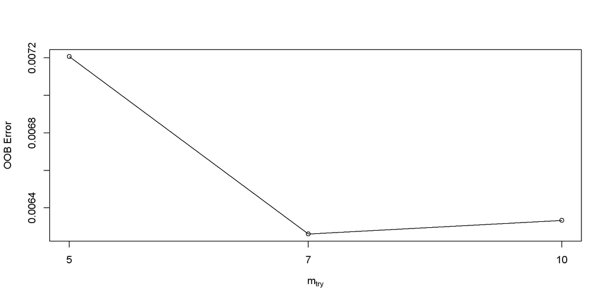

```r
# Random Forest model tuning
set.seed(seed0)
bestmtry <- tuneRF(training.train[-which(names(training.train) == 'classe')],
                   training.train$classe, ntreeTry = rf_ntrees,
                   stepFactor = 1.5, improve = 0.01,
                   trace = TRUE, plot = TRUE, dobest = FALSE)
```

```r
best.mtry <- bestmtry[as.numeric(which.min(bestmtry[, "OOBError"])),"mtry"]
best.OOBError <- bestmtry[as.numeric(which.min(bestmtry[, "OOBError"])),"OOBError"]
```

As shown at the above $tuneRF()$ diagram, the $mtry$ value $7$ gives the lowest OOB Error ($0.0062605$). So, our random forest model will be tuned based on this:

```r
set.seed(seed0)
# Model tuning
model.tuned <- randomForest(classe ~ ., data = training.validate, mtry = best.mtry,
                            ntree = rf_ntrees.tune, keep.forest = TRUE, proximity = TRUE,
                            importance = TRUE, test = training.validate)
model.tuned
```

```
##
## Call:
##  randomForest(formula = classe ~ ., data = training.validate,      mtry = best.mtry, ntree = rf_ntrees.tune, keep.forest = TRUE,      proximity = TRUE, importance = TRUE, test = training.validate)
##                Type of random forest: classification
##                      Number of trees: 500
## No. of variables tried at each split: 7
##
##         OOB estimate of  error rate: 1.94%
## Confusion matrix:
##      A    B   C   D    E class.error
## A 1668    4   2   0    0 0.003584229
## B   20 1105  14   0    0 0.029850746
## C    0   24 995   7    0 0.030214425
## D    1    0  32 929    2 0.036307054
## E    0    1   3   4 1074 0.007393715
```

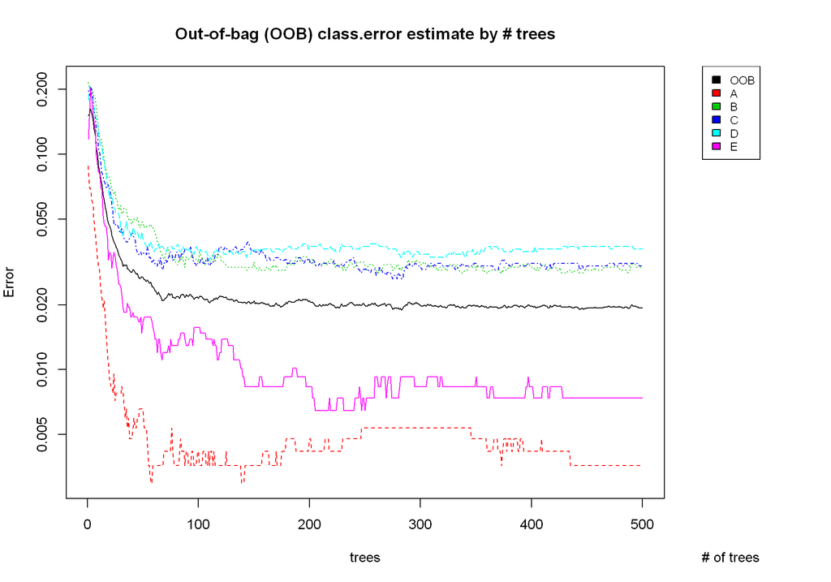

```r
# Plot the Out-of-bag error estimates
layout(matrix(c(1, 2), nrow = 1), width = c(4, 1))
par(mar = c(5, 4, 4, 0))
plot(model.tuned, log = "y", main = "Out-of-bag (OOB) class.error estimate by # trees")
par(mar = c(5, 0, 4, 2))
plot(c(0, 1), type = "n", axes = F, xlab = "# of trees", ylab = "Class. error")
legend("top", colnames(model.tuned$err.rate), col = 1:6, cex = 0.8, fill = 1:6)
```

## Variable importance

We can also see the model variables’ importance at the following Variable Importance Plot:

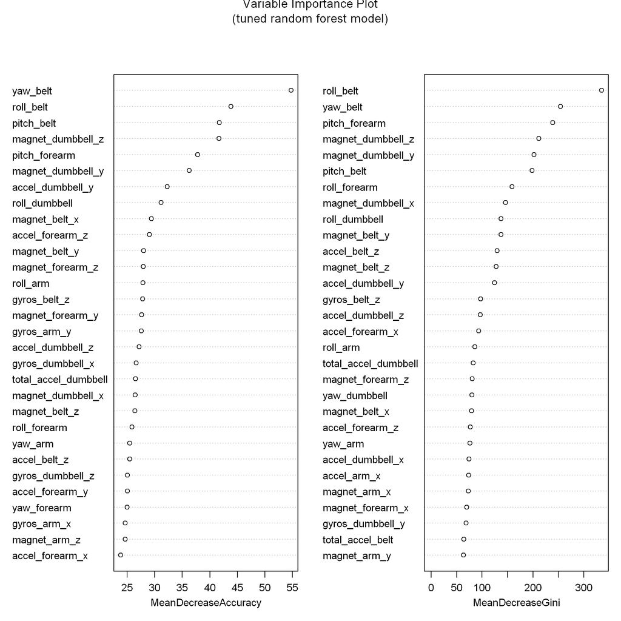

```r
# Variable Importance Plot
varImpPlot(model.tuned, main="Variable Importance Plot\n(tuned random forest model)")
```

# Testing set prediction

Finally, we apply the model built on the original testing data set, in order to predict the $20$ samples’ $classe$ variable:

```r
# Testing set prediction
predictions <- predict(model.tuned, newdata = testing)
data.frame('Classe(Predicted)' = predictions)
```

```
##    Classe.Predicted.
## 1                  B
## 2                  A
## 3                  B
## 4                  A
## 5                  A
## 6                  E
## 7                  D
## 8                  B
## 9                  A
## 10                 A
## 11                 B
## 12                 C
## 13                 B
## 14                 A
## 15                 E
## 16                 E
## 17                 A
## 18                 B
## 19                 B
## 20                 B
```

# Appendix #1

## Training set inspection

```r
# Instant data touching
levels(data.training$user_name)
```

```
## [1] "adelmo"   "carlitos" "charles"  "eurico"   "jeremy"   "pedro"
```

```r
levels(data.training$classe)
```

```
## [1] "A" "B" "C" "D" "E"
```

```r
str(data.training, list.len = 999)
```

```
## 'data.frame':    19622 obs. of  160 variables:
##  $ X                       : int  1 2 3 4 5 6 7 8 9 10 ...
##  $ user_name               : Factor w/ 6 levels "adelmo","carlitos",..: 2 2 2 2 2 2 2 2 2 2 ...
##  $ raw_timestamp_part_1    : int  1323084231 1323084231 1323084231 1323084232 1323084232 1323084232 1323084232 1323084232 1323084232 1323084232 ...
##  $ raw_timestamp_part_2    : int  788290 808298 820366 120339 196328 304277 368296 440390 484323 484434 ...
##  $ cvtd_timestamp          : Factor w/ 20 levels "02/12/2011 13:32",..: 9 9 9 9 9 9 9 9 9 9 ...
##  $ new_window              : Factor w/ 2 levels "no","yes": 1 1 1 1 1 1 1 1 1 1 ...
##  $ num_window              : int  11 11 11 12 12 12 12 12 12 12 ...
##  $ roll_belt               : num  1.41 1.41 1.42 1.48 1.48 1.45 1.42 1.42 1.43 1.45 ...
##  $ pitch_belt              : num  8.07 8.07 8.07 8.05 8.07 8.06 8.09 8.13 8.16 8.17 ...
##  $ yaw_belt                : num  -94.4 -94.4 -94.4 -94.4 -94.4 -94.4 -94.4 -94.4 -94.4 -94.4 ...
##  $ total_accel_belt        : int  3 3 3 3 3 3 3 3 3 3 ...
##  $ kurtosis_roll_belt      : Factor w/ 397 levels "","-0.016850",..: 1 1 1 1 1 1 1 1 1 1 ...
##  $ kurtosis_picth_belt     : Factor w/ 317 levels "","-0.021887",..: 1 1 1 1 1 1 1 1 1 1 ...
##  $ kurtosis_yaw_belt       : Factor w/ 2 levels "","#DIV/0!": 1 1 1 1 1 1 1 1 1 1 ...
```

[output cut: 146 more lines]

```r
summary(data.training)
```

```
##        X            user_name    raw_timestamp_part_1 raw_timestamp_part_2
##  Min.   :    1   adelmo  :3892   Min.   :1.322e+09    Min.   :   294
##  1st Qu.: 4906   carlitos:3112   1st Qu.:1.323e+09    1st Qu.:252912
##  Median : 9812   charles :3536   Median :1.323e+09    Median :496380
##  Mean   : 9812   eurico  :3070   Mean   :1.323e+09    Mean   :500656
##  3rd Qu.:14717   jeremy  :3402   3rd Qu.:1.323e+09    3rd Qu.:751891
##  Max.   :19622   pedro   :2610   Max.   :1.323e+09    Max.   :998801
##
##           cvtd_timestamp  new_window    num_window      roll_belt
##  28/11/2011 14:14: 1498   no :19216   Min.   :  1.0   Min.   :-28.90
##  05/12/2011 11:24: 1497   yes:  406   1st Qu.:222.0   1st Qu.:  1.10
##  30/11/2011 17:11: 1440               Median :424.0   Median :113.00
##  05/12/2011 11:25: 1425               Mean   :430.6   Mean   : 64.41
##  02/12/2011 14:57: 1380               3rd Qu.:644.0   3rd Qu.:123.00
##  02/12/2011 13:34: 1375               Max.   :864.0   Max.   :162.00
##  (Other)         :11007
##    pitch_belt          yaw_belt       total_accel_belt kurtosis_roll_belt
##  Min.   :-55.8000   Min.   :-180.00   Min.   : 0.00             :19216
##  1st Qu.:  1.7600   1st Qu.: -88.30   1st Qu.: 3.00    #DIV/0!  :   10
##  Median :  5.2800   Median : -13.00   Median :17.00    -1.908453:    2
##  Mean   :  0.3053   Mean   : -11.21   Mean   :11.31    -0.016850:    1
##  3rd Qu.: 14.9000   3rd Qu.:  12.90   3rd Qu.:18.00    -0.021024:    1
##  Max.   : 60.3000   Max.   : 179.00   Max.   :29.00    -0.025513:    1
##                                                        (Other)  :  391
##  kurtosis_picth_belt kurtosis_yaw_belt skewness_roll_belt
##           :19216            :19216              :19216
##  #DIV/0!  :   32     #DIV/0!:  406     #DIV/0!  :    9
##  47.000000:    4                       0.000000 :    4
##  -0.150950:    3                       0.422463 :    2
##  -0.684748:    3                       -0.003095:    1
##  -1.750749:    3                       -0.010002:    1
##  (Other)  :  361                       (Other)  :  389
##  skewness_roll_belt.1 skewness_yaw_belt max_roll_belt     max_picth_belt
##           :19216             :19216     Min.   :-94.300   Min.   : 3.00
##  #DIV/0!  :   32      #DIV/0!:  406     1st Qu.:-88.000   1st Qu.: 5.00
##  0.000000 :    4                        Median : -5.100   Median :18.00
##  -2.156553:    3                        Mean   : -6.667   Mean   :12.92
##  -3.072669:    3                        3rd Qu.: 18.500   3rd Qu.:19.00
##  -6.324555:    3                        Max.   :180.000   Max.   :30.00
##  (Other)  :  361                        NA's   :19216     NA's   :19216
```

[output cut: 313 more lines]

```
##  Min.   :-446.00   Min.   :-1280.0   Min.   :-896.0   Min.   :-973.0
##  1st Qu.:-182.00   1st Qu.: -616.0   1st Qu.:   2.0   1st Qu.: 191.0
##  Median : -39.00   Median : -378.0   Median : 591.0   Median : 511.0
##  Mean   : -55.29   Mean   : -312.6   Mean   : 380.1   Mean   : 393.6
##  3rd Qu.:  26.00   3rd Qu.:  -73.0   3rd Qu.: 737.0   3rd Qu.: 653.0
##  Max.   : 291.00   Max.   :  672.0   Max.   :1480.0   Max.   :1090.0
##
##  classe
##  A:5580
##  B:3797
##  C:3422
##  D:3216
##  E:3607
##
##
```

# Appendix #2

## Testing set inspection

```r
# Instant data touching
levels(data.testing$user_name)
```

```
## [1] "adelmo"   "carlitos" "charles"  "eurico"   "jeremy"   "pedro"
```

```r
data.testing$problem_id
```

```
##  [1]  1  2  3  4  5  6  7  8  9 10 11 12 13 14 15 16 17 18 19 20
```

```r
str(data.testing, list.len = 999)
```

```
## 'data.frame':    20 obs. of  160 variables:
##  $ X                       : int  1 2 3 4 5 6 7 8 9 10 ...
##  $ user_name               : Factor w/ 6 levels "adelmo","carlitos",..: 6 5 5 1 4 5 5 5 2 3 ...
##  $ raw_timestamp_part_1    : int  1323095002 1322673067 1322673075 1322832789 1322489635 1322673149 1322673128 1322673076 1323084240 1322837822 ...
##  $ raw_timestamp_part_2    : int  868349 778725 342967 560311 814776 510661 766645 54671 916313 384285 ...
##  $ cvtd_timestamp          : Factor w/ 11 levels "02/12/2011 13:33",..: 5 10 10 1 6 11 11 10 3 2 ...
##  $ new_window              : Factor w/ 1 level "no": 1 1 1 1 1 1 1 1 1 1 ...
##  $ num_window              : int  74 431 439 194 235 504 485 440 323 664 ...
##  $ roll_belt               : num  123 1.02 0.87 125 1.35 -5.92 1.2 0.43 0.93 114 ...
##  $ pitch_belt              : num  27 4.87 1.82 -41.6 3.33 1.59 4.44 4.15 6.72 22.4 ...
##  $ yaw_belt                : num  -4.75 -88.9 -88.5 162 -88.6 -87.7 -87.3 -88.5 -93.7 -13.1 ...
##  $ total_accel_belt        : int  20 4 5 17 3 4 4 4 4 18 ...
##  $ kurtosis_roll_belt      : logi  NA NA NA NA NA NA ...
##  $ kurtosis_picth_belt     : logi  NA NA NA NA NA NA ...
##  $ kurtosis_yaw_belt       : logi  NA NA NA NA NA NA ...
```

[output cut: 146 more lines]

```r
summary(data.testing)
```

```
##        X            user_name raw_timestamp_part_1 raw_timestamp_part_2
##  Min.   : 1.00   adelmo  :1   Min.   :1.322e+09    Min.   : 36553
##  1st Qu.: 5.75   carlitos:3   1st Qu.:1.323e+09    1st Qu.:268655
##  Median :10.50   charles :1   Median :1.323e+09    Median :530706
##  Mean   :10.50   eurico  :4   Mean   :1.323e+09    Mean   :512167
##  3rd Qu.:15.25   jeremy  :8   3rd Qu.:1.323e+09    3rd Qu.:787738
##  Max.   :20.00   pedro   :3   Max.   :1.323e+09    Max.   :920315
##
##           cvtd_timestamp new_window   num_window      roll_belt
##  30/11/2011 17:11:4      no:20      Min.   : 48.0   Min.   : -5.9200
##  05/12/2011 11:24:3                 1st Qu.:250.0   1st Qu.:  0.9075
##  30/11/2011 17:12:3                 Median :384.5   Median :  1.1100
##  05/12/2011 14:23:2                 Mean   :379.6   Mean   : 31.3055
##  28/11/2011 14:14:2                 3rd Qu.:467.0   3rd Qu.: 32.5050
##  02/12/2011 13:33:1                 Max.   :859.0   Max.   :129.0000
##  (Other)         :5
##    pitch_belt         yaw_belt      total_accel_belt kurtosis_roll_belt
##  Min.   :-41.600   Min.   :-93.70   Min.   : 2.00    Mode:logical
##  1st Qu.:  3.013   1st Qu.:-88.62   1st Qu.: 3.00    NA's:20
##  Median :  4.655   Median :-87.85   Median : 4.00
##  Mean   :  5.824   Mean   :-59.30   Mean   : 7.55
##  3rd Qu.:  6.135   3rd Qu.:-63.50   3rd Qu.: 8.00
##  Max.   : 27.800   Max.   :162.00   Max.   :21.00
##
##  kurtosis_picth_belt kurtosis_yaw_belt skewness_roll_belt
##  Mode:logical        Mode:logical      Mode:logical
##  NA's:20             NA's:20           NA's:20
##
##
##
##
##
##  skewness_roll_belt.1 skewness_yaw_belt max_roll_belt  max_picth_belt
##  Mode:logical         Mode:logical      Mode:logical   Mode:logical
##  NA's:20              NA's:20           NA's:20        NA's:20
##
##
##
##
##
```

[output cut: 289 more lines]

```
##  Min.   :-1.2600   Min.   :-212.0   Min.   :-331.0   Min.   :-282.0
##  1st Qu.:-0.0975   1st Qu.:-114.8   1st Qu.:   8.5   1st Qu.:-199.0
##  Median : 0.2300   Median :  86.0   Median : 138.0   Median :-148.5
##  Mean   : 0.2610   Mean   :  38.8   Mean   : 125.3   Mean   : -93.7
##  3rd Qu.: 0.7625   3rd Qu.: 166.2   3rd Qu.: 268.0   3rd Qu.: -31.0
##  Max.   : 1.8000   Max.   : 232.0   Max.   : 406.0   Max.   : 179.0
##
##  magnet_forearm_x magnet_forearm_y magnet_forearm_z   problem_id
##  Min.   :-714.0   Min.   :-787.0   Min.   :-32.0    Min.   : 1.00
##  1st Qu.:-427.2   1st Qu.:-328.8   1st Qu.:275.2    1st Qu.: 5.75
##  Median :-189.5   Median : 487.0   Median :491.5    Median :10.50
##  Mean   :-159.2   Mean   : 191.8   Mean   :460.2    Mean   :10.50
##  3rd Qu.:  41.5   3rd Qu.: 720.8   3rd Qu.:661.5    3rd Qu.:15.25
##  Max.   : 532.0   Max.   : 800.0   Max.   :884.0    Max.   :20.00
##
```